# Paper Reviewed: Investing with Cryptocurrencies -- evaluating their potential for portfolio allocation strategies

> According to the authors, they present the broadest study on investing with cryptocurrencies (CCs) conducted so far. They calculate out-of-sample performance and diversification benefits for the most prevalent portfolio construction methods, including mean-variance optimization, risk-parity, and maximumdiversification strategies, as well as combined strategies.
- Literature Highlights of CC investments:
  - remarkably high average realized returns and and correspondingly high risk and uncertainty.
  - high volatility; also there are unfavorable properties in CC investments, e.g., frequent pricing bubbles, accumulation of jumps and even evidence of price manipulation
  - low correlations of CC returns with those of traditional financial assets and other CCs -> potential diversification effects
  - returns of CCs have even heavier tails as compared to those of equities
- Findings:
  - CCs can improve the risk-return profile of portfolios, but their benefit depends on investor objectives.
  - CCs contribute to diversification.
  - Illiquidity of CCs hurts out-of-sample performance, however, their diversification benefits persist.
- Data used in the paper:
  - over the period 2015-01-01 to 2019-12-31
  - focus on solid CCs and also sidestep ICOs: excluding coins that did not already circulate in January 2015, went extinct before December 2019, or have only patchy price series

| Model | Abbr. |
| --- | --- |
| *model-free strategies* equally-weighted | EW |
| *Risk-oriented strategies* Mean-Variance Mean-CVaR Equal Risk Contribution Maximum Diversification | minVar MinCVaR ERC MD |
| *Return-oriented strategies* Risk-Return - max return | RR-MaxRet |
| *Risk-Return-oriented strategies* Mean-Variance - max Sharpe | MV-S |
| *Combination models* Naive Combination Weight Combination | CombNaive Comb |

- Methodology highlights:
  - 9 asset allocation models (table above)
  - rule out short selling, a standard assumption in CCs.
  - performance metrics:
    - cumulative wealth
    - Sharpe ratio
    - certainty equivalent
    - adjusted Sharpe ratio (mitigate the drawback of normality assumption for returns)
    - portfolio turnover
    - target turnover
  - diversification metrics:
    - portfolio diversification index
    - effective N
    - diversification ratio

# Quick Replication (with Extensional Analytics)

- 18 Assets: 13 traditional assets + 5 CCs

| Type | Asset |
| --- | --- |
| Equity | S&P100 EURO STOXX 50 NIKKEI225 FTSE100 SSE (Shanghai Stock Exchange) index |
| Commodity | S&P GSCI Gold Futures |
| Real Estate | FTSE EN Dev Mkts Rel Est ETF |
| Currency | EUR/USD CNY/USD GBP/USD JPY/USD |
| Bond | US Treasury Bond ETF |
| Crypto | BTC-USD PPC-USD NMC-USD LTC-USD NVC-USD |

- Contribution:
  - include weekends into consideration since currency and CCs are traded 24/7.
  - extend the analysis period to until last year.
  - add detailed and more analytics, e.g, drawdown, rolling sharpe ratio, etc.
- TODO:
  - use data of higher quality from professional data sources like Bloomberg.
  - as illiquidity can be another major concern over cryptocurrency investing, it would be good to add liquidity constraints into the strategy construction.
  - add robustness analysis
  - add fine-tuned, new construction strategy

*Footnote*: some extra notes are that there are a few typos in the public paper, which I attempted to correct in the following code (e.g., formula (2) on page 16, formula (6) on page 17)

```python
# data
import datetime as dt
import pandas as pd
import numpy as np

# plot
import seaborn as sns
import matplotlib.pyplot as plt
import matplotlib.ticker as ticker
import matplotlib.dates as mdates
#import warnings

# in-house module
from util import *
from strats_analyzer import StratsAnalyzer

# formatting
pd.options.display.float_format = '{:,.4f}'.format

# helpers
import pickle
plt.rcParams["figure.figsize"] = (15,6)
```

```python
# Asset Universe:
# - equity: S&P100, EURO STOXX 50, NIKKEI225, FTSE100, SSE (Shanghai Stock Exchange) index
# - commodity & RE: S&P GSCI, Gold Futures, FTSE EN Dev Mkts Rel Est ETF
# - currency: EUR/USD,CNY/USD,GBP/USD=,JPY/USD
# - bond: US Treasury Bond ETF
```

```python
tickers = [
    "^OEX","^STOXX50E","^N225","^FTSE","000001.SS",
    "^SPGSCI", "GC=F", "FFR",
    "EURUSD=X","CNYUSD=X","GBPUSD=X","JPYUSD=X",
    "GOVT",
    "BTC-USD", "PPC-USD", "NMC-USD", "LTC-USD", "NVC-USD"
]

start = dt.datetime(2015, 12, 31)
end = dt.datetime(2021, 12, 31)

# save hist price data
# with open("./price_data.pickle", "wb") as file:
#     pickle.dump(data, file)
```

```python
# # uncomment below to read raw data
# with open("./price_data.pickle", 'rb') as file:
#     data = pickle.load(file)

data = get_data(tickers, start, end)
log_ret_data = compute_ret(data)
```

[output not shown]

```python
log_ret_data.columns
```

```
Index(['^OEX', '^STOXX50E', '^N225', '^FTSE', '000001.SS', '^SPGSCI', 'GC=F',
       'FFR', 'EURUSD=X', 'CNYUSD=X', 'GBPUSD=X', 'JPYUSD=X', 'GOVT',
       'BTC-USD', 'PPC-USD', 'NMC-USD', 'LTC-USD', 'NVC-USD'],
      dtype='object')
```

```python
log_ret_data.head()
```

|  | ^OEX | ^STOXX50E | ^N225 | ^FTSE | 000001.SS | ^SPGSCI | GC=F | FFR | EURUSD=X | CNYUSD=X | GBPUSD=X | JPYUSD=X | GOVT | BTC-USD | PPC-USD | NMC-USD | LTC-USD | NVC-USD |
| --- | --- | --- | --- | --- | --- | --- | --- | --- | --- | --- | --- | --- | --- | --- | --- | --- | --- | --- |
| 2016-01-01 | 0.0000 | 0.0000 | 0.0000 | 0.0000 | 0.0000 | 0.0000 | 0.0000 | 0.0000 | -0.0069 | -0.0004 | -0.0055 | 0.0013 | 0.0000 | 0.0087 | -0.0189 | 0.0502 | 0.0082 | 0.0453 |
| 2016-01-02 | 0.0000 | 0.0000 | 0.0000 | 0.0000 | 0.0000 | 0.0000 | 0.0000 | 0.0000 | 0.0000 | 0.0000 | 0.0000 | 0.0000 | 0.0000 | -0.0021 | 0.0217 | -0.0772 | -0.0019 | -0.0107 |
| 2016-01-03 | 0.0000 | 0.0000 | 0.0000 | 0.0000 | 0.0000 | 0.0000 | 0.0000 | 0.0000 | 0.0000 | 0.0000 | 0.0000 | 0.0000 | 0.0000 | -0.0079 | 0.0033 | 0.0842 | -0.0055 | 0.0159 |
| 2016-01-04 | -0.0165 | 0.0000 | 0.0000 | -0.0241 | -0.0711 | -0.0065 | 0.0139 | -0.0194 | -0.0005 | 0.0000 | -0.0001 | -0.0002 | 0.0024 | 0.0071 | -0.0104 | -0.0493 | 0.0035 | -0.0268 |
| 2016-01-05 | 0.0012 | 0.0042 | -0.0042 | 0.0072 | -0.0026 | -0.0080 | 0.0031 | 0.0131 | -0.0024 | -0.0064 | -0.0016 | 0.0070 | -0.0012 | -0.0026 | -0.0336 | -0.0554 | -0.0074 | -0.0125 |

## Descriptive Statistics

```python
log_ret_data.describe(percentiles=(0.1,0.9)).iloc[1:,:].T
```

|  | mean | std | min | 10% | 50% | 90% | max |
| --- | --- | --- | --- | --- | --- | --- | --- |
| ^OEX | 0.0004 | 0.0096 | -0.1229 | -0.0068 | 0.0000 | 0.0090 | 0.0965 |
| ^STOXX50E | 0.0001 | 0.0101 | -0.1324 | -0.0090 | 0.0000 | 0.0093 | 0.0883 |
| ^N225 | 0.0002 | 0.0104 | -0.0825 | -0.0096 | 0.0000 | 0.0107 | 0.0773 |
| ^FTSE | 0.0001 | 0.0088 | -0.1151 | -0.0079 | 0.0000 | 0.0085 | 0.0867 |
| 000001.SS | 0.0000 | 0.0093 | -0.0804 | -0.0087 | 0.0000 | 0.0087 | 0.0555 |
| ^SPGSCI | 0.0003 | 0.0117 | -0.1252 | -0.0117 | 0.0000 | 0.0120 | 0.0768 |
| GC=F | 0.0002 | 0.0077 | -0.0511 | -0.0073 | 0.0000 | 0.0080 | 0.0578 |
| FFR | 0.0002 | 0.0097 | -0.1590 | -0.0079 | 0.0000 | 0.0084 | 0.0776 |
| EURUSD=X | 0.0000 | 0.0037 | -0.0281 | -0.0042 | 0.0000 | 0.0044 | 0.0177 |
| CNYUSD=X | 0.0000 | 0.0022 | -0.0158 | -0.0023 | 0.0000 | 0.0022 | 0.0142 |
| GBPUSD=X | -0.0000 | 0.0051 | -0.0791 | -0.0054 | 0.0000 | 0.0052 | 0.0291 |
| JPYUSD=X | 0.0000 | 0.0043 | -0.0267 | -0.0046 | 0.0000 | 0.0046 | 0.0314 |
| GOVT | 0.0001 | 0.0022 | -0.0225 | -0.0023 | 0.0000 | 0.0024 | 0.0223 |
| BTC-USD | 0.0021 | 0.0399 | -0.4647 | -0.0400 | 0.0022 | 0.0439 | 0.2251 |
| PPC-USD | 0.0003 | 0.0714 | -0.6647 | -0.0679 | -0.0014 | 0.0718 | 0.5674 |
| NMC-USD | 0.0005 | 0.0925 | -1.1598 | -0.0759 | -0.0011 | 0.0794 | 0.7503 |
| LTC-USD | 0.0017 | 0.0570 | -0.4491 | -0.0533 | 0.0001 | 0.0597 | 0.5114 |
| NVC-USD | -0.0008 | 0.1984 | -2.2177 | -0.0685 | 0.0000 | 0.0676 | 1.9747 |

low to non-existent correlations between CCs and traditional assets

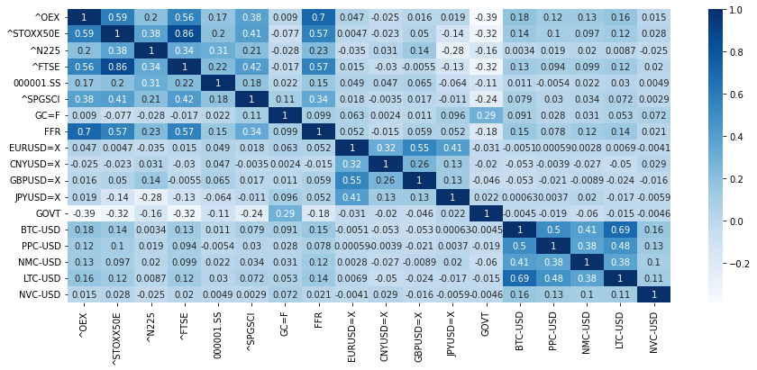

```python
corr = log_ret_data.corr()
sns.heatmap(corr, cmap="Blues", annot=True)
plt.show()
```

strong leptokurtic (heavy-tailed) nature of CC returns

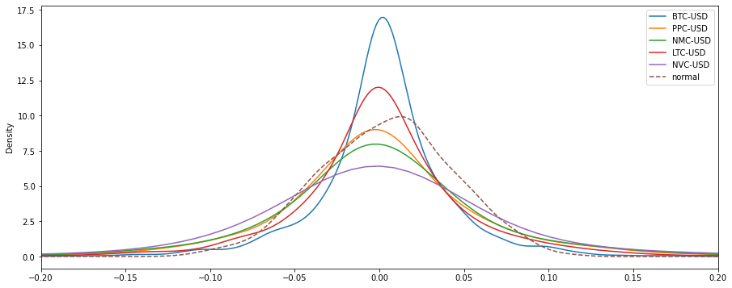

```python
btc_mean, btc_std = log_ret_data["BTC-USD"].mean(),log_ret_data["BTC-USD"].std()
fig, ax = plt.subplots()
log_ret_data.iloc[:,-5:].plot.kde(ax=ax)
pd.Series(np.random.normal(loc=btc_mean, scale=btc_std, size=1000)).plot.kde(ax=ax, label="normal",style='--')
plt.legend()
ax.set_xlim(-0.2, 0.2)
plt.show()
```

## Portfolio Construction

```python
analyzer = StratsAnalyzer()
```

```python
my_strats = ["EW","MinVar","MV-S","RR-MaxRet","MinCVar","ERC","MD"]
# portfolio weights/returns on Traditional asset classes only
portfolio_wo_ccs = analyzer.get_port_ret(log_ret_data.iloc[:,:-5], strats=my_strats)
# portfolio weights/returns on Traditional asset classes + Cryptocurrencies
portfolio_wt_ccs = analyzer.get_port_ret(log_ret_data, strats=my_strats)
```

```
Working on EW...
Working on MinVar...
Working on MV-S...
Working on RR-MaxRet...
Working on MinCVar...
Working on ERC...
Working on MD...
```

```
Done!
Working on Model Combinations...
Working on Combination of Model Weights through Bootstrapping...
Bootstrapping Done!
Working on EW...
Working on MinVar...
Working on MV-S...
Working on RR-MaxRet...
Working on MinCVar...
Working on ERC...
Working on MD...
```

```
Done!
Working on Model Combinations...
Working on Combination of Model Weights through Bootstrapping...
Bootstrapping Done!
```

## Performance Discussion

```python
# util functions for performance/reporting
def plot_cumu_rets(ret_data, title):
    fig, ax = plt.subplots()
    dtFmt = mdates.DateFormatter('%Y-%b') # define the formatting
    ret_data.plot(ax=ax)
    plt.gca().xaxis.set_major_formatter(dtFmt)
    plt.gca().xaxis.set_major_locator(mdates.MonthLocator(interval=6))
    plt.minorticks_off()
    #portfolio_wt_ccs_cumu_rets[["EW","RR-MaxRet"]].plot(ax=ax, secondary_y=True)
    plt.title(title)
    plt.show()

def combine_metrics(df_wo_ccs, df_wt_ccs, reindex=True):
    df1, df2 = df_wo_ccs.copy(), df_wt_ccs.copy()
    df1.index = [tag + " (Without CCs)" for tag in df1.index]
    df2.index = [(tag + " (With CCs)" if tag != "^OEX" else tag + " (S&P100)") for tag in df2.index]
    res = pd.concat([df1,df2])
    if reindex:
        tmp_index = list(res.index)
        new_index = [tmp_index[-1],]+tmp_index[0:-1]
        res = res.loc[new_index]
    return res
```

### cumulative wealth

```python
portfolio_wo_ccs_rets = pd.concat([strat["daily_ret"] for strat in portfolio_wo_ccs.values()], axis=1)
portfolio_wt_ccs_rets = pd.concat([strat["daily_ret"] for strat in portfolio_wt_ccs.values()], axis=1)
# add benchmark sp100
portfolio_wt_ccs_rets = portfolio_wt_ccs_rets.join(np.exp(log_ret_data["^OEX"]))

# compute cumulative returns
portfolio_wo_ccs_cumu_rets = portfolio_wo_ccs_rets.cumprod()
portfolio_wt_ccs_cumu_rets = portfolio_wt_ccs_rets.cumprod()
```

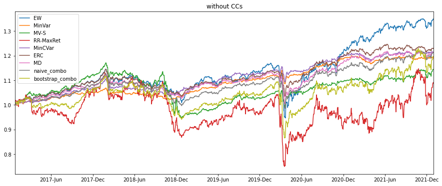

```python
plot_cumu_rets(portfolio_wo_ccs_cumu_rets,"without CCs")
```

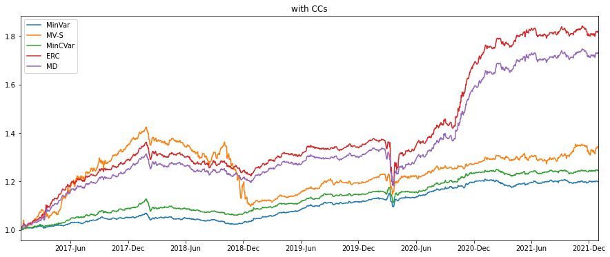

```python
plot_cumu_rets(portfolio_wt_ccs_cumu_rets[["MinVar","MV-S","MinCVar","ERC","MD"]],"with CCs")
```

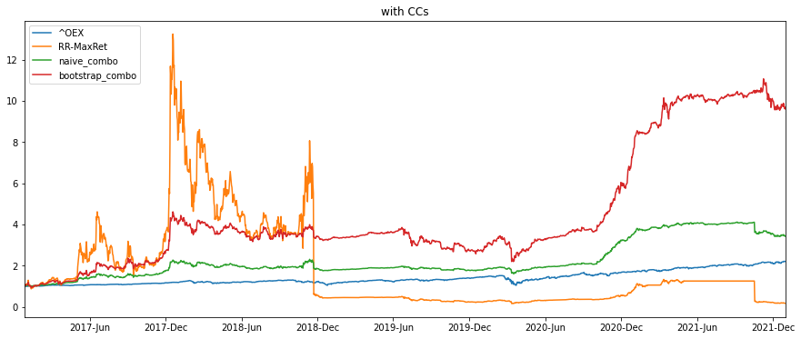

```python
plot_cumu_rets(portfolio_wt_ccs_cumu_rets[["^OEX","RR-MaxRet","naive_combo","bootstrap_combo"]],"with CCs")
```

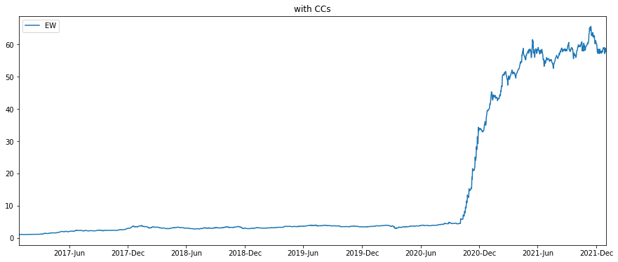

```python
plot_cumu_rets(portfolio_wt_ccs_cumu_rets[["EW"]],"with CCs")
```

```python
cw_wo_ccs = portfolio_wo_ccs_cumu_rets.iloc[-1,:]
cw_wt_ccs = portfolio_wt_ccs_cumu_rets.iloc[-1,:]

cw_final = combine_metrics(cw_wo_ccs, cw_wt_ccs)
cw_final.name = "Cumulative Return - Whole Period"
```

### maximum drawdown

```python
portfolio_wo_ccs_mdd = portfolio_wo_ccs_cumu_rets.apply(analyzer.max_drawdown, axis=0)
portfolio_wt_ccs_mdd = portfolio_wt_ccs_cumu_rets.apply(analyzer.max_drawdown, axis=0)
```

```python
mdd_final = combine_metrics(portfolio_wo_ccs_mdd, portfolio_wt_ccs_mdd)
mdd_final.name = "Maximum Drawdown - Whole Period"
```

### Sharpe Ratio

```python
plt.rcParams["figure.figsize"] = (20,10)
```

```python
rolling_windows = 120
portfolio_wo_ccs_rol_SR = (portfolio_wo_ccs_rets - 1).rolling(f'{rolling_windows}d').apply(analyzer.rolling_sharpe).iloc[rolling_windows:,:]
portfolio_wo_ccs_expand_SR = (portfolio_wo_ccs_rets - 1).expanding(rolling_windows).apply(analyzer.rolling_sharpe).iloc[rolling_windows:,:]

portfolio_wt_ccs_rol_SR = (portfolio_wt_ccs_rets - 1).rolling(f'{rolling_windows}d').apply(analyzer.rolling_sharpe).iloc[rolling_windows:,:]
portfolio_wt_ccs_expand_SR = (portfolio_wt_ccs_rets - 1).expanding(rolling_windows).apply(analyzer.rolling_sharpe).iloc[rolling_windows:,:]
```

```python
#plot_cumu_rets(portfolio_wo_ccs_rol_SR,"Rolling Monthly Sharpe Ratio without CCs")
```

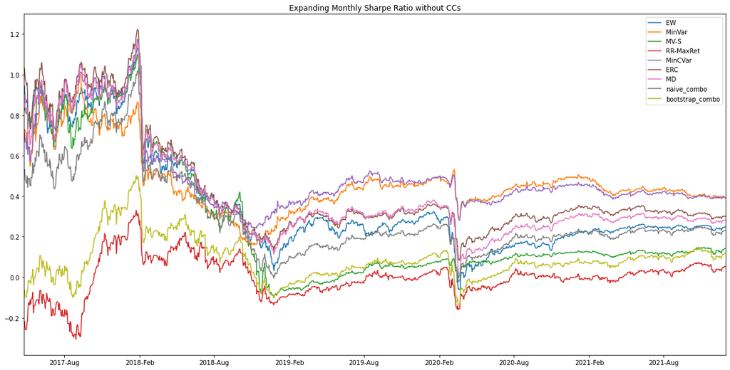

```python
plot_cumu_rets(portfolio_wo_ccs_expand_SR,"Expanding Monthly Sharpe Ratio without CCs")
```

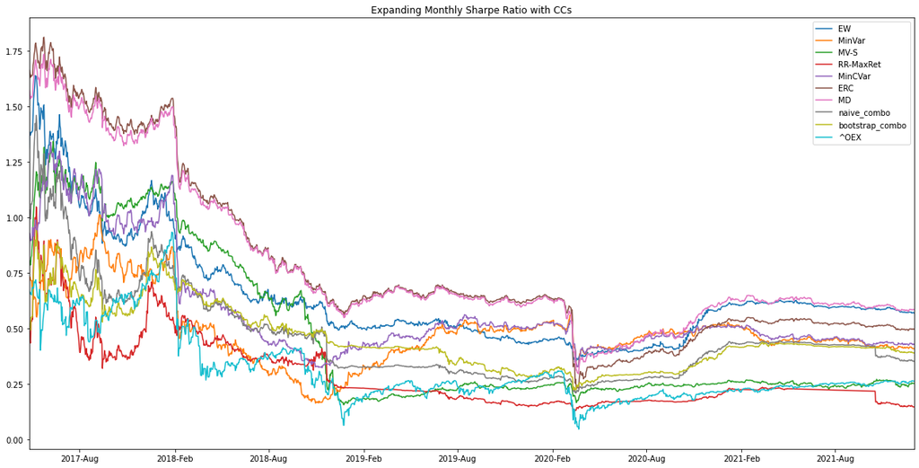

```python
plot_cumu_rets(portfolio_wt_ccs_expand_SR,"Expanding Monthly Sharpe Ratio with CCs")
```

```python
sr_mean = combine_metrics(portfolio_wo_ccs_rol_SR.mean(), portfolio_wt_ccs_rol_SR.mean())
sr_median = combine_metrics(portfolio_wo_ccs_rol_SR.median(), portfolio_wt_ccs_rol_SR.median())
sr_final = combine_metrics(portfolio_wo_ccs_expand_SR.iloc[-1,:], portfolio_wt_ccs_expand_SR.iloc[-1,:])

sr_mean.name = "(Monthly) Sharpe Ratio - Rolling Mean"
sr_median.name = "(Monthly) Sharpe Ratio - Rolling Median"
sr_final.name = "(Monthly) Sharpe Ratio - Whole Period"
```

### Adjust Sharpe Ratio (account for non-normality of returns)

```python
rolling_windows = 120
portfolio_wo_ccs_rol_ASR = (portfolio_wo_ccs_rets - 1).rolling(f'{rolling_windows}d').apply(analyzer.rolling_adj_sharpe).iloc[rolling_windows:,:]
portfolio_wo_ccs_expand_ASR = (portfolio_wo_ccs_rets - 1).expanding(rolling_windows).apply(analyzer.rolling_adj_sharpe).iloc[rolling_windows:,:]

portfolio_wt_ccs_rol_ASR = (portfolio_wt_ccs_rets - 1).rolling(f'{rolling_windows}d').apply(analyzer.rolling_adj_sharpe).iloc[rolling_windows:,:]
portfolio_wt_ccs_expand_ASR = (portfolio_wt_ccs_rets - 1).expanding(rolling_windows).apply(analyzer.rolling_adj_sharpe).iloc[rolling_windows:,:]
```

[figure not shown]

```python
plot_cumu_rets(portfolio_wo_ccs_expand_ASR,"Expanding Monthly Sharpe Ratio without CCs")
```

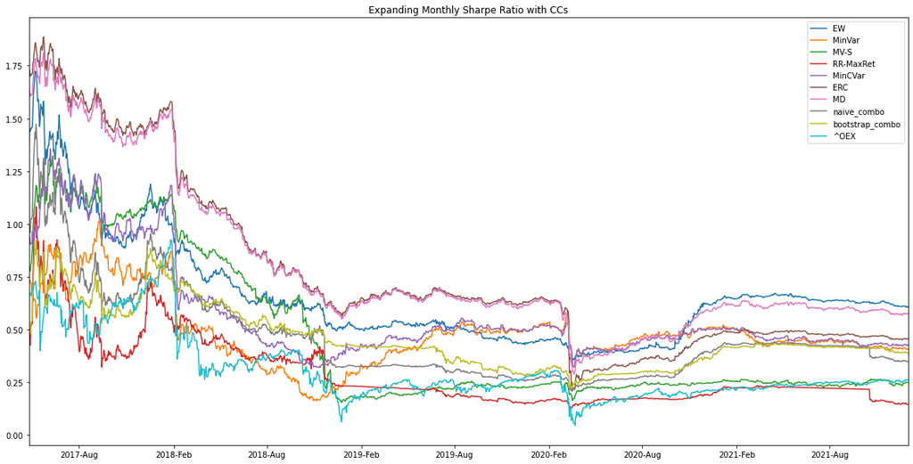

```python
plot_cumu_rets(portfolio_wt_ccs_expand_ASR,"Expanding Monthly Sharpe Ratio with CCs")
```

```python
asr_min = combine_metrics(portfolio_wo_ccs_rol_ASR.min(), portfolio_wt_ccs_rol_ASR.min())
asr_mean = combine_metrics(portfolio_wo_ccs_rol_ASR.mean(), portfolio_wt_ccs_rol_ASR.mean())
asr_median = combine_metrics(portfolio_wo_ccs_rol_ASR.median(), portfolio_wt_ccs_rol_ASR.median())
asr_final = combine_metrics(portfolio_wo_ccs_expand_ASR.iloc[-1,:], portfolio_wt_ccs_expand_ASR.iloc[-1,:])

asr_min.name = "(Monthly) Adjusted Sharpe Ratio - Rolling Min"
asr_mean.name = "(Monthly) Adjusted Sharpe Ratio - Rolling Mean"
asr_median.name = "(Monthly) Adjusted Sharpe Ratio - Rolling Median"
asr_final.name = "(Monthly) Adjusted Sharpe Ratio - Whole Period"
```

### Target Turnover

```python
portfolio_wo_ccs_tto = pd.Series({key: analyzer.compute_tto(val["weight"]) for key, val in portfolio_wo_ccs.items()})
portfolio_wt_ccs_tto = pd.Series({key: analyzer.compute_tto(val["weight"]) for key, val in portfolio_wt_ccs.items()})
```

```python
tto_final = combine_metrics(portfolio_wo_ccs_tto, portfolio_wt_ccs_tto, reindex=False)
tto_final.name = "Target Turnover - Whole Period"
```

### Diversification

#### Effective N

```python
# without CCs
portfolio_wo_ccs_effN = {}
for strat, val in portfolio_wo_ccs.items():
    portfolio_wo_ccs_effN[strat] = val["weight"].apply(analyzer.compute_rol_effN, axis=1)

portfolio_wo_ccs_effN = pd.DataFrame(portfolio_wo_ccs_effN)
```

```python
# without CCs
portfolio_wt_ccs_effN = {}
for strat, val in portfolio_wt_ccs.items():
    portfolio_wt_ccs_effN[strat] = val["weight"].apply(analyzer.compute_rol_effN, axis=1)

portfolio_wt_ccs_effN = pd.DataFrame(portfolio_wt_ccs_effN)
```

```python
effN_mean = combine_metrics(portfolio_wo_ccs_effN.mean(), portfolio_wt_ccs_effN.mean(), reindex=False)
effN_mean.name = "Effective N - Mean"
```

#### PDI

```python
# without CCs
portfolio_wo_ccs_rol_PDI = {}
for strat, val in portfolio_wo_ccs.items():
    portfolio_wo_ccs_rol_PDI[strat] = val["weight"].apply(lambda row: analyzer.compute_rol_PDI(row, log_ret_data.iloc[:,:-5], window_size=360), axis=1)

portfolio_wo_ccs_rol_PDI = pd.DataFrame(portfolio_wo_ccs_rol_PDI)
portfolio_wo_ccs_rol_PDI = portfolio_wo_ccs_rol_PDI.apply(np.real, axis=0)
```

```python
# with CCs
portfolio_wt_ccs_rol_PDI = {}
for strat, val in portfolio_wt_ccs.items():
    portfolio_wt_ccs_rol_PDI[strat] = val["weight"].apply(lambda row: analyzer.compute_rol_PDI(row, log_ret_data, window_size=360), axis=1)

portfolio_wt_ccs_rol_PDI = pd.DataFrame(portfolio_wt_ccs_rol_PDI)
portfolio_wt_ccs_rol_PDI = portfolio_wt_ccs_rol_PDI.apply(np.real, axis=0)
```

```python
pdi_mean = combine_metrics(portfolio_wo_ccs_rol_PDI.mean(), portfolio_wt_ccs_rol_PDI.mean(), reindex=False)
pdi_mean.name = "PDI - Mean"
```

### Reporting

```python
reporting = pd.concat([cw_final,mdd_final,sr_mean,sr_median,sr_final,asr_min,asr_median,asr_final,tto_final,effN_mean,pdi_mean], axis=1)
```

```python
reporting.to_clipboard()
```